# TP Régression multi-linéaire - Mardoché Clabessi

### (r) Analyse de la normalité des résidus.

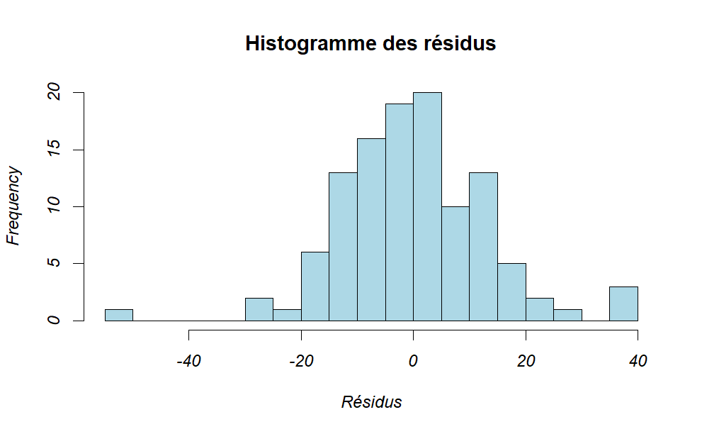

```r
# Supposons que regc soit votre modèle de régression
residus <- residuals(regc)

# 1. Histogramme des résidus
hist(residus, breaks = 20, main = "Histogramme des résidus", xlab = "Résidus", col = "lightblue", border = "black")
```

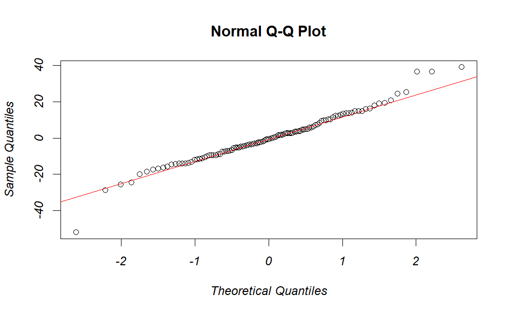

```r
# 2. Q-Q plot
qqnorm(residus)
qqline(residus, col = "red")  # Ligne de référence
```

```r
# 3. Test de Shapiro-Wilk
shapiro_test <- shapiro.test(residus)
print(shapiro_test)
```

```
    Shapiro-Wilk normality test

data:  residus
W = 0.97333, p-value = 0.02419
```

```r
# Interpréter les résultats
if (shapiro_test$p.value > 0.05) {
  cat("Les résidus suivent une distribution normale (p-value =", shapiro_test$p.value, ")\n")
} else {
  cat("Les résidus ne suivent pas une distribution normale (p-value =", shapiro_test$p.value, ")\n")
}
```

```
Les résidus ne suivent pas une distribution normale (p-value = 0.02418848 )
```

#### Interprétation

- **Histogramme** : L’histogramme ressemble à une distribution normale en forme de cloche, ce qui est un bon indicateur de normalité.
- **Q-Q plot** : Les points suivent la généralement ligne droite rouge, cela suggère que les résidus suivraient une distribution normale.
- **Test de Shapiro-Wilk** : La p-value est inférieure à 0.05, cela indique que les résidus ne suivent pas une distribution normale.

## 10. Proposer un modèle de régression de O3 sur les variables T15, Ne12, Vx et maxO3v.

### Création du modèle de régression

Nous allons utiliser la fonction `lm()` pour créer le modèle. Voici comment procéder :

```r
# Créer le modèle de régression
modele_regression <- lm(maxO3 ~ T15 + Ne12 + Vx9 + Vx12 + Vx15 + maxO3v, data = ozone)

# Afficher le résumé du modèle
summary(modele_regression)
```

```
Call:
lm(formula = maxO3 ~ T15 + Ne12 + Vx9 + Vx12 + Vx15 + maxO3v,
    data = ozone)

Residuals:
    Min      1Q  Median      3Q     Max
-54.228  -8.462   0.289   8.521  40.269

Coefficients:
            Estimate Std. Error t value Pr(>|t|)
(Intercept) 16.73736   12.65503   1.323    0.189
T15          2.46676    0.46963   5.253 7.90e-07 ***
Ne12        -2.26542    0.88563  -2.558    0.012 *
Vx9          1.03599    0.86882   1.192    0.236
Vx12        -0.18680    1.05328  -0.177    0.860
Vx15         0.82526    0.92703   0.890    0.375
maxO3v       0.34745    0.06097   5.699 1.12e-07 ***
---
Signif. codes:
0 ‘***’ 0.001 ‘**’ 0.01 ‘*’ 0.05 ‘.’ 0.1 ‘ ’ 1

Residual standard error: 14.82 on 105 degrees of freedom
Multiple R-squared:  0.7385,    Adjusted R-squared:  0.7236
F-statistic: 49.43 on 6 and 105 DF,  p-value: < 2.2e-16
```

### Interprétation des résultats

#### Interprétation des coefficients :

- **(Intercept)**: Lorsque toutes les variables indépendantes sont nulles, la valeur d’O3 serait de 16.74. Cependant, cela peut ne pas avoir de sens pratique.
- **T15**: Pour chaque augmentation d’une unité de T15, la valeur d’O3 augmente en moyenne de 2.47 unités. Cette variable est très significative (p < 0.001).
- **Ne12**: Pour chaque augmentation d’une unité de Ne12, la valeur d’O3 diminue en moyenne de 2.27 unités. Cette variable est significative (p = 0.012).
- **Vx9, Vx12, Vx15**: Ces variables ne sont pas significatives, car leurs p-values sont supérieures à 0.05. Cela suggère qu’elles n’ont pas d’effet discernable sur O3 dans le contexte de ce modèle.
- **maxO3v**: Pour chaque augmentation d’une unité de maxO3v, la valeur d’O3 augmente en moyenne de 0.35 unités. Cette variable est également très significative (p < 0.001).

#### Qualité de l’ajustement du modèle

- **Résidu standard error**: 14.82 indique la dispersion des résidus autour de la ligne de régression.
- **Multiple R-squared**: 0.7385 signifie que le modèle explique environ 73.85% de la variance dans O3. Cela est relativement bon, mais il reste de la variance inexpliquée.
- **Adjusted R-squared**: 0.7236 ajuste le R-squared en fonction du nombre de variables dans le modèle, indiquant une bonne qualité d’ajustement.
- **F-statistic**: 49.43 avec un p-value < 2.2e-16 indique que le modèle est significatif globalement, suggérant qu’au moins une des variables indépendantes a un effet significatif sur la variable dépendante.

### Comparaison avec le modèle complet

```r
# Créer le modèle de régression
summary(modele_regression)
```

```
Call:
lm(formula = maxO3 ~ T15 + Ne12 + Vx9 + Vx12 + Vx15 + maxO3v,
    data = ozone)

Residuals:
    Min      1Q  Median      3Q     Max
-54.228  -8.462   0.289   8.521  40.269

Coefficients:
            Estimate Std. Error t value Pr(>|t|)
(Intercept) 16.73736   12.65503   1.323    0.189
T15          2.46676    0.46963   5.253 7.90e-07 ***
Ne12        -2.26542    0.88563  -2.558    0.012 *
Vx9          1.03599    0.86882   1.192    0.236
Vx12        -0.18680    1.05328  -0.177    0.860
Vx15         0.82526    0.92703   0.890    0.375
maxO3v       0.34745    0.06097   5.699 1.12e-07 ***
---
Signif. codes:
0 ‘***’ 0.001 ‘**’ 0.01 ‘*’ 0.05 ‘.’ 0.1 ‘ ’ 1

Residual standard error: 14.82 on 105 degrees of freedom
Multiple R-squared:  0.7385,    Adjusted R-squared:  0.7236
F-statistic: 49.43 on 6 and 105 DF,  p-value: < 2.2e-16
```

```r
# Créer le modèle complet avec toutes les variables
regc <- lm(maxO3 ~ ., data = ozone)
summary(regc)
```

```
Call:
lm(formula = maxO3 ~ ., data = ozone)

Residuals:
    Min      1Q  Median      3Q     Max
-51.727  -8.809  -0.506   7.651  39.005

Coefficients:
            Estimate Std. Error t value Pr(>|t|)
(Intercept) 26.18680   19.39154   1.350   0.1801
obs         -0.01390    0.01544  -0.901   0.3700
T9          -0.33757    1.23883  -0.272   0.7858
T12          2.21084    1.50064   1.473   0.1440
T15          0.53524    1.19196   0.449   0.6544
Ne9         -2.15401    0.96205  -2.239   0.0275 *
Ne12        -0.41298    1.44365  -0.286   0.7754
Ne15         0.04083    1.03890   0.039   0.9687
Vx9          0.27804    1.01434   0.274   0.7846
Vx12         0.72713    1.27065   0.572   0.5685
Vx15         0.86415    0.96506   0.895   0.3728
maxO3v       0.33848    0.06738   5.024 2.34e-06 ***
ventNord     1.45415    6.77760   0.215   0.8306
ventOuest    6.62801    8.34445   0.794   0.4290
ventSud      6.66156    7.30003   0.913   0.3638
pluieSec     2.30046    3.64090   0.632   0.5290
---
Signif. codes:
0 ‘***’ 0.001 ‘**’ 0.01 ‘*’ 0.05 ‘.’ 0.1 ‘ ’ 1

Residual standard error: 14.52 on 96 degrees of freedom
Multiple R-squared:  0.7705,    Adjusted R-squared:  0.7347
F-statistic: 21.49 on 15 and 96 DF,  p-value: < 2.2e-16
```

```r
# Comparer les modèles
anova(regc, modele_regression)
```

```
Analysis of Variance Table

Model 1: maxO3 ~ obs + T9 + T12 + T15 + Ne9 + Ne12 + Ne15 + Vx9 + Vx12 +
    Vx15 + maxO3v + vent + pluie
Model 2: maxO3 ~ T15 + Ne12 + Vx9 + Vx12 + Vx15 + maxO3v
  Res.Df   RSS Df Sum of Sq      F Pr(>F)
1     96 20239
2    105 23058 -9   -2819.1 1.4858 0.1641
```

**R-squared et Adjusted R-squared** : Le **modèle complet** a un R-squared plus élevé (0.7705) par rapport au **nouveau modèle** (0.7385), ce qui indique qu’il explique mieux la variance de maxO3.

**Significativité des coefficients** : Le **modèle complet** contient des variables supplémentaires qui peuvent influencer maxO3, comme Ne9, ce qui n’est pas le cas dans le **nouveau modèle**.

**Résidus** : Bien que les deux modèles montrent une dispersion comparable des résidus, le **modèle complet** a des résidus légèrement plus petits en valeur absolue, indiquant une meilleure précision.

## 11. Comparaison des modèles linéaires

### Le modèle linéaire par rapport à quelle variable est-il raisonnable ?

Le modèle linéaire que nous avons ajusté est raisonnable par rapport à la variable **maxO3**. Cette variable est notre variable dépendante, et nous essayons d’expliquer sa variabilité à l’aide des autres variables indépendantes présentes dans le jeu de données **ozone**. Le choix des variables indépendantes dans le modèle doit être fondé sur leur pertinence théorique et leur capacité à expliquer la variabilité de **maxO3**.

### Influence de chaque variable

Pour analyser l’influence de chaque variable, nous nous basons sur les résultats des coefficients de régression , ainsi que sur leur significativité. Voici une interprétation des résultats :

- **T15** : Coefficient positif (2.46676) et très significatif (p < 0.001). Cela signifie qu’une augmentation de T15 est associée à une augmentation de **maxO3**, indiquant que cette variable a une forte influence positive sur **maxO3**.
- **Ne12** : Coefficient négatif (-2.26542) et significatif (p = 0.012). Cela indique qu’une augmentation de Ne12 est associée à une diminution de **maxO3**, suggérant une influence négative.
- **Vx9, Vx12, Vx15** : Ces variables ont des coefficients non significatifs (p > 0.05). Cela suggère qu’elles n’ont pas d’influence notable sur **maxO3** dans le modèle.
- **maxO3v** : Coefficient positif (0.34745) et très significatif (p < 0.001). Cela indique que cette variable a une influence positive sur **maxO3**.

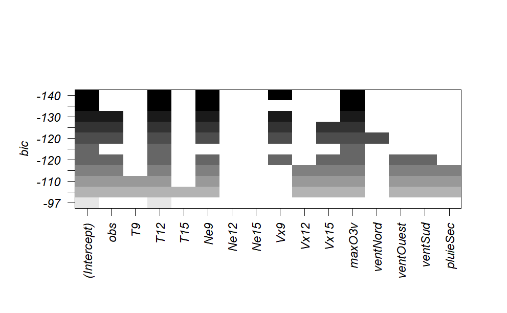

```r
# Ajustement du modèle avec le package leaps
choix <- regsubsets(maxO3 ~ ., data=ozone, nbest=1, nvmax=11)

# Visualisation des résultats
plot(choix)
```